# Adult Census Income

### 2.1 LASSO Regularised Regression

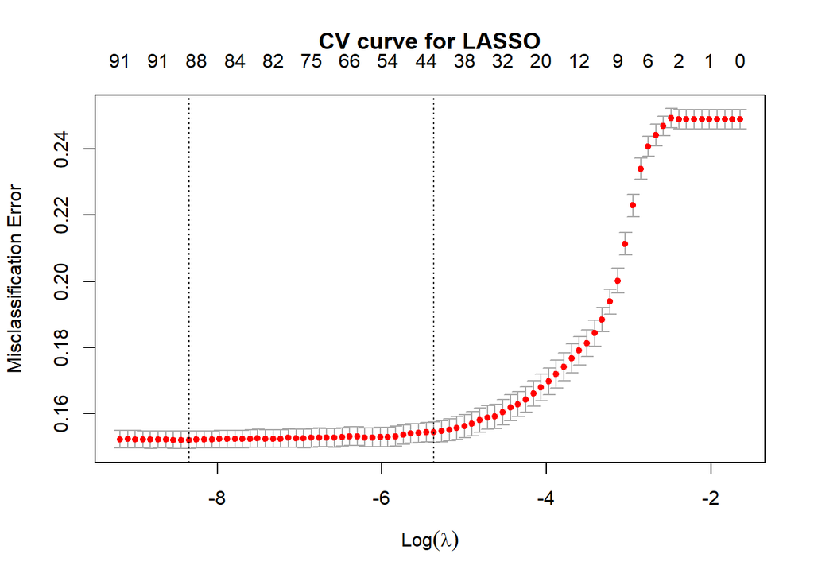

```r
set.seed(123)

# Define X matrix and y vector
X <- model.matrix(income~. -1 + age*hours_per_week, data = data_clean) # -1 => remove intercept
y <- as.numeric(as.character(data_clean$income))

cv_lasso <- cv.glmnet(X, y, alpha = 1, family = 'binomial', type.measure = 'class')
plot(cv_lasso); title('CV curve for LASSO', line = 2)
```

```r
# find optimal lambda
opt_lambda <- cv_lasso$lambda.min
lasso_model <- cv_lasso$glmnet.fit # glmnet(x = X, y = y, alpha = 1, family = "binomial")

# Extract coefficients
lasso_betas <- as.matrix(coef(lasso_model, s = opt_lambda))
n_lasso_betas <- sum(lasso_betas != 0)

cat("Optimal lambda:", opt_lambda, "\n")
```

```
## Optimal lambda: 0.0002374363
```

```r
cat("Number of non-zero coefficients:", n_lasso_betas, "\n")
```

```
## Number of non-zero coefficients: 92
```

### 2.2 Ridge Regression

We expect most of the variables to be related to `income`, so instead of doing variable selection, we can retain all and let Ridge do shrinkage.

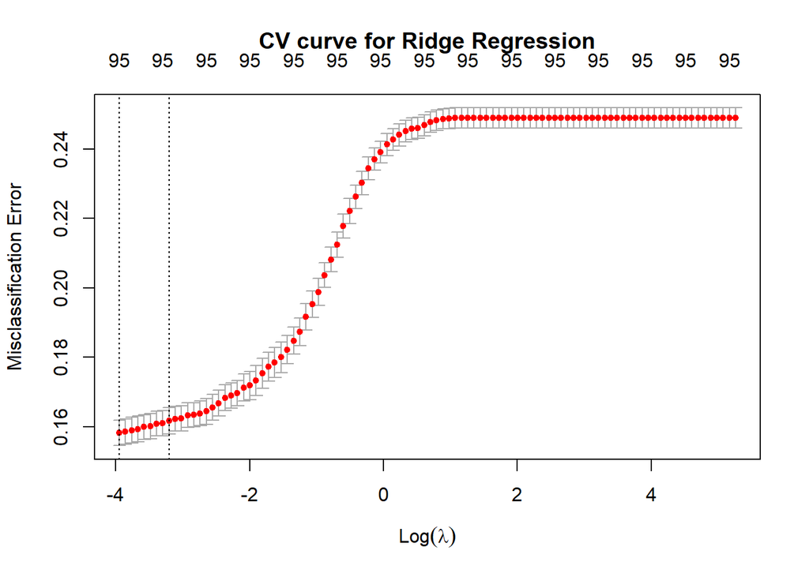

```r
set.seed(123)

#X <- model.matrix(income~. -1 + age*hours_per_week, data = data_clean) # -1 => remove intercept
#y <- as.numeric(as.character(data_clean$income))

cv_ridge <- cv.glmnet(X, y, alpha = 0, family = 'binomial', type.measure = 'class')
plot(cv_ridge); title('CV curve for Ridge Regression', line = 2)
```

```r
# Find the optimal lambda and fit to model
opt_lambda_ridge <- cv_ridge$lambda.min
ridge_model <- cv_ridge$glmnet.fit #glmnet(X, y, alpha = 0, lambda = opt_lambda_ridge)

# Extract coefficients
ridge_betas <- as.matrix(coef(ridge_model, s = opt_lambda_ridge))
n_ridge_betas <- sum(ridge_betas != 0)

cat("Optimal lambda for Ridge:", opt_lambda_ridge, "\n")
```

```
## Optimal lambda for Ridge: 0.01925919
```

```r
cat("Number of non-zero coefficients in Ridge:", n_ridge_betas, "\n")
```

```
## Number of non-zero coefficients in Ridge: 96
```

Note that Ridge retains all predictors by shrinking their coefficients toward zero, whereas LASSO selectively shrinks some coefficients to exactly zero, effectively performing feature selection.

### 3. Decision Tree

Note that decision trees handle interactions implicitly through recursive splitting.

```r
set.seed(123)

# Fit tree
decision_tree <- rpart(income ~ ., data = data_clean, method = "class") # classification
decision_tree
```

```
## n= 30161
##
## node), split, n, loss, yval, (yprob)
##       * denotes terminal node
##
##  1) root 30161 7508 0 (0.75106926 0.24893074)
##    2) relationship=Not-in-family,Other-relative,Own-child,Unmarried 16292 1135 0 (0.93033391 0.06966609)
##      4) capital_gain< 7073.5 15992  845 0 (0.94716108 0.05283892) *
##      5) capital_gain>=7073.5 300   10 1 (0.03333333 0.96666667) *
##    3) relationship=Husband,Wife 13869 6373 0 (0.54048598 0.45951402)
##      6) education=10th,11th,12th,1st-4th,5th-6th,7th-8th,9th,Assoc-acdm,Assoc-voc,HS-grad,Preschool,Some-college 9719 3322 0 (0.65819529 0.34180471)
##       12) capital_gain< 5095.5 9219 2831 0 (0.69291680 0.30708320) *
##       13) capital_gain>=5095.5 500    9 1 (0.01800000 0.98200000) *
##      7) education=Bachelors,Doctorate,Masters,Prof-school 4150 1099 1 (0.26481928 0.73518072) *
```

```r
printcp(decision_tree) # Choose CP = 0.010000 (4 splits)
```

```
##
## Classification tree:
## rpart(formula = income ~ ., data = data_clean, method = "class")
##
## Variables actually used in tree construction:
## [1] capital_gain education    relationship
##
## Root node error: 7508/30161 = 0.24893
##
## n= 30161
##
##         CP nsplit rel error  xerror      xstd
## 1 0.129995      0   1.00000 1.00000 0.0100018
## 2 0.064198      2   0.74001 0.74001 0.0089670
## 3 0.037294      3   0.67581 0.67581 0.0086527
## 4 0.010000      4   0.63852 0.63852 0.0084574
```

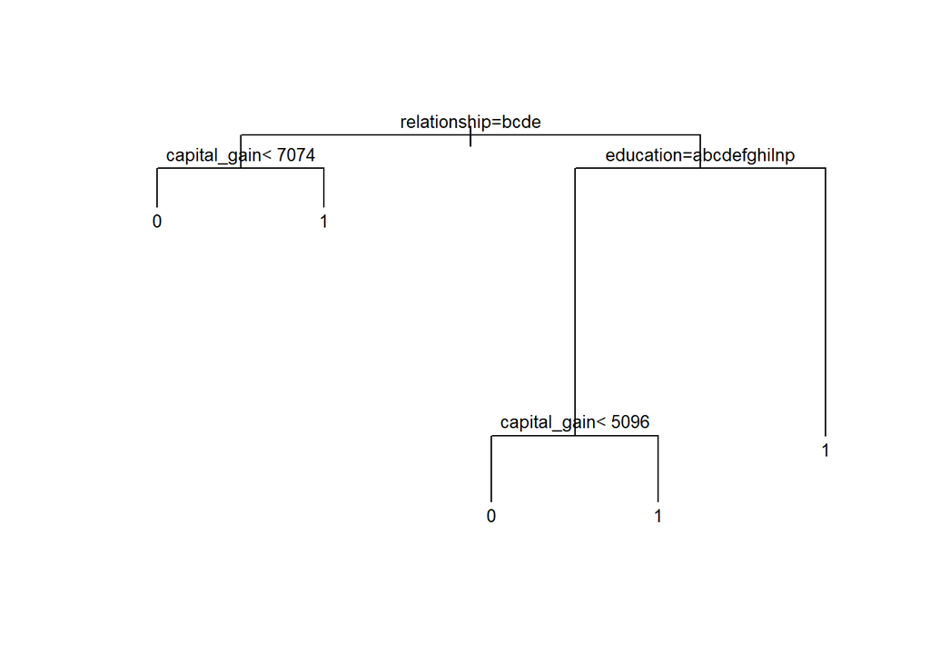

```r
# Prune tree
optimal_cp <- 0.010000
pruned_tree <- prune(decision_tree, cp=optimal_cp)
plot(pruned_tree, margin=0.03); text(pruned_tree, cex=0.8)
```

The decision tree has the best predictive ability when it has 4 splits as shown above.

### 4. Random Forest

Note that Random Forests and XGBoost (ensemble methods) are based on decision trees, so they capture interactions implicitly through their tree-building process (the difference is the training process:

- RFs builds each tree independently and use the majority vote or average across trees to make predictions => final model is an aggregate of all the tree’s results
- XGBoost builds trees sequentially, where each tree focuses on the errors (residuals) of the previous trees).

```r
set.seed(123)
# Optimize mtry: balances bias-variance tradeoff and minimizes Out-Of-Bag error.
mtrys <- c(1, 2,3, 4, 5, 8, 11)

# initialize array
forests <- vector('list', length(mtrys))

# Loop through each mtry value and grow forests, just keep the OOB error
for (i in seq_along(mtrys)) {
  forest <- ranger(income ~ .,
                        data=data_clean,
                        num.trees = 500,
                        mtry=mtrys[i],
                        min.node.size = 15 # categorical
                        )
  forests[[i]] <- forest
}

# Get OOB errors first
oob_error_mtry <- vector('numeric', length(forests))

for (i in seq_along(oob_error_mtry)) {
  oob_error_mtry[i] <- forests[[i]]$prediction.error
}
oob_error_mtry
```

```
## [1] 0.1721428 0.1381917 0.1357382 0.1377607 0.1408110 0.1452206 0.1473426
```

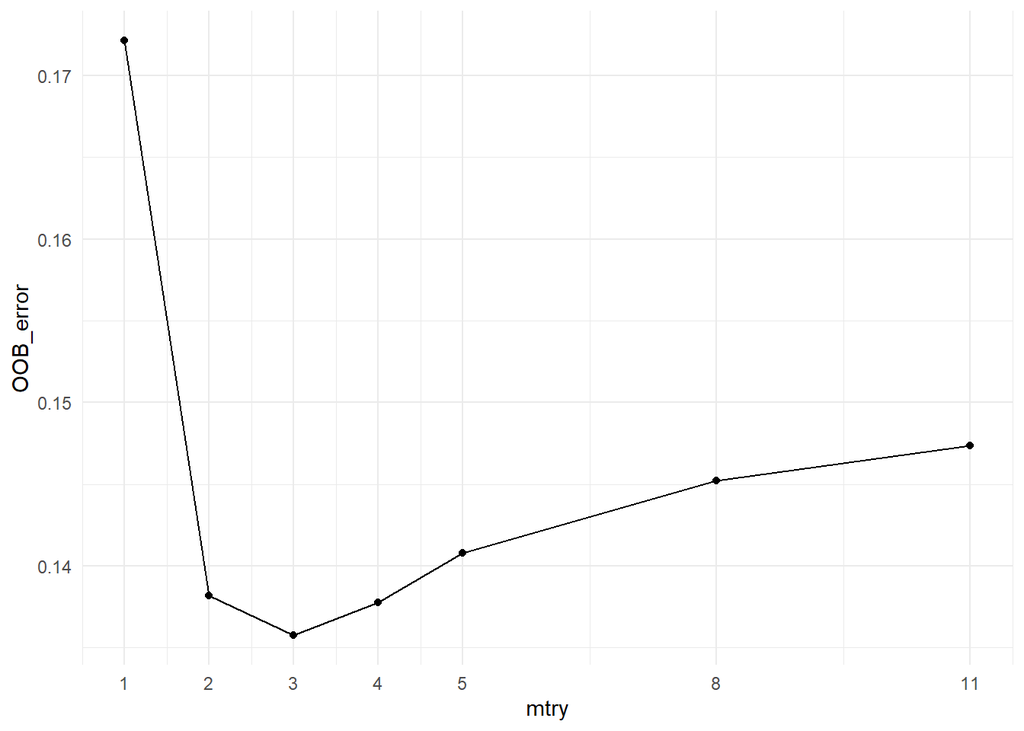

```r
# Make into data frame for set-up
dataframe_mtry <- data.frame(mtry = mtrys, OOB_error = oob_error_mtry)

# Plot
ggplot(dataframe_mtry) +
  geom_line(aes(x=mtry, y=OOB_error)) +
  geom_point(aes(x=mtry, y=OOB_error)) +
  scale_x_continuous(breaks = mtrys) +
  theme_minimal()
```

The mtry value with the lowest OOB error is 3.

```r
# Fit Random Forest model
random_forest <- ranger(income ~ .,
                      data=data_clean,
                      num.trees = 500, # 500 trees is sufficient
                      mtry=3,
                      min.node.size = 15, # categorical (30,000 observations, avoid overfitting)
                      importance = 'impurity',
                      )
print(random_forest)
```

```
## Ranger result
##
## Call:
##  ranger(income ~ ., data = data_clean, num.trees = 500, mtry = 3,      min.node.size = 15, importance = "impurity", )
##
## Type:                             Classification
## Number of trees:                  500
## Sample size:                      30161
## Number of independent variables:  12
## Mtry:                             3
## Target node size:                 15
## Variable importance mode:         impurity
## Splitrule:                        gini
## OOB prediction error:             13.69 %
```

```r
print(sort(random_forest$variable.importance, decreasing = TRUE)) # Order of predictor importance
```

```
##   capital_gain   relationship            age marital_status      education
##     1346.36643     1136.99497      943.46455      783.29114      731.50063
## hours_per_week     occupation   capital_loss      workclass native_country
##      615.60354      599.15672      435.71298      265.56184      122.71736
##            sex           race
##      117.90901       99.73172
```

### 5. XGBoost

```r
set.seed(123)

# Prepare data for XGBoost
X_mat <- model.matrix(income ~ . -1 + age*hours_per_week, data = data_clean) # exclude intercept
y_label <- as.numeric(as.character(data_clean$income)) # convert factor back to numeric

# Convert to DMatrix format (required by XGBoost)
dtrain <- xgb.DMatrix(data = X_mat, label = y_label)

# Define parameters for XGBoost
params <- list(
  objective = "binary:logistic", # binary classification
  eval_metric = "error", # error rate
  max_depth = 6, # max depth of trees (try 4-10, shallower trees generalize better, deeper trees => more complex patterns)
  eta = 0.15, # learning rate (experiment with 0.01 to 0.2)
  gamma = 0.1, # min loss reduction (try 0, 0.1, 0.2: higher => simpler)
  colsample_bytree = 0.7, # fraction of features to be randomly sampled for each tree, higher => more complex (try 0.5-0.9)
  subsample = 0.7 # fraction of data to be randomly sampled for each tree (try 0.6-1)
)

# Perform cross-validation to find the optimal number of rounds (trees)
cv_xgb <- xgb.cv(
  params = params,
  data = dtrain,
  nrounds = 100, # maximum number of boosting iterations
  nfold = 10, # 10-fold cross-validation
  verbose = TRUE, # display training process
  early_stopping_rounds = 10 # stop if no improvement in 10 rounds
)
```

```
## Multiple eval metrics are present. Will use test_error for early stopping.
## Will train until test_error hasn't improved in 10 rounds.
##
```

```r
# Get best number of rounds (trees) based on cross-validation
best_nrounds <- cv_xgb$best_iteration

# Train final XGBoost model with optimal number of rounds
xgb_model <- xgb.train(
  params = params,
  data = dtrain,
  nrounds = best_nrounds
)
```

```r
# Get feature importance
importance <- xgb.importance(model = xgb_model)
importance
```

```
##                                 Feature         Gain        Cover    Frequency
##                                  <char>        <num>        <num>        <num>
##  1:    marital_statusMarried-civ-spouse 2.248373e-01 4.629806e-02 0.0198412698
##  2:                        capital_gain 1.894191e-01 1.338631e-01 0.0818070818
##  3:                  age:hours_per_week 8.906016e-02 9.363413e-02 0.1852869353
##  4:                        capital_loss 6.920480e-02 8.688025e-02 0.0573870574
##  5:                                 age 6.308080e-02 6.826627e-02 0.1376678877
##  6:         marital_statusNever-married 3.570759e-02 1.139054e-02 0.0082417582
##  7:            occupationProf-specialty 3.550382e-02 1.700733e-02 0.0192307692
##  8:                      hours_per_week 3.505180e-02 4.699999e-02 0.1047008547
##  9:                  educationBachelors 2.940517e-02 2.034472e-02 0.0219780220
## 10:                             sexMale 2.490428e-02 1.460387e-02 0.0192307692
## 11:           occupationExec-managerial 2.423153e-02 2.082940e-02 0.0173992674
## 12:                    relationshipWife 1.973566e-02 1.459160e-02 0.0134310134
## 13:                    educationMasters 1.863724e-02 1.833372e-02 0.0131257631
```

[output cut: 63 more lines]

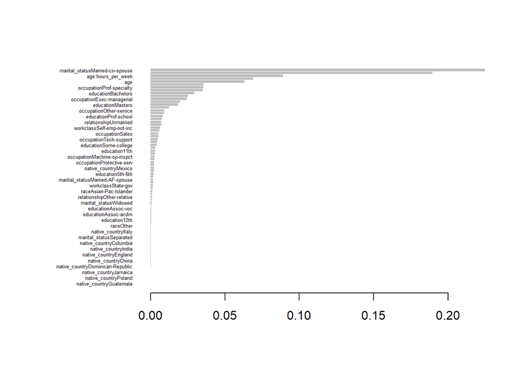

```r
# Plot feature importance
xgb.plot.importance(importance)
```

```r
print(xgb_model)
```

```
## ##### xgb.Booster
## raw: 291.4 Kb
## call:
##   xgb.train(params = params, data = dtrain, nrounds = best_nrounds)
## params (as set within xgb.train):
##   objective = "binary:logistic", eval_metric = "error", max_depth = "6", eta = "0.15", gamma = "0.1", colsample_bytree = "0.7", subsample = "0.7", validate_parameters = "TRUE"
## xgb.attributes:
##   niter
## callbacks:
##   cb.print.evaluation(period = print_every_n)
## # of features: 95
## niter: 100
## nfeatures : 95
```

The predictors are shown above and are ordered by importance by the XGBoost model. The predictors that are the most important according to the model are all valid and make sense as discussed in the Data Exploration section from before.

# 3. Performance Evaluation

### Load adult.test and Modify

```r
url_test <- "https://archive.ics.uci.edu/ml/machine-learning-databases/adult/adult.test"

# Load Data
adult_test <- read_csv(url_test, skip = 1, # skip the first line
                       col_names = column_names)
dim(adult_test) # 15 columns
```

```
## [1] 16281    15
```

```r
# Remove 'fnlwgt' and 'education_num' columns
adult_test <- adult_test[, -which(colnames(adult_test) %in% c("fnlwgt", "education_num"))]
dim(adult_test) # should be 13 columns
```

```
## [1] 16281    13
```

```r
# Check all column names are the same as the training data
all(colnames(adult_test) == colnames(data_clean)) # TRUE
```

```
## [1] TRUE
```

```r
# Remove NAs
adult_test[adult_test== '?'] <- NA
sum(is.na(adult_test)) # 2203 NAs
```

```
## [1] 2203
```

```r
adult_test <- na.omit(adult_test)
any(is.na(adult_test)) # no more NAs
```

```
## [1] FALSE
```

```r
# convert response to binary factor
adult_test$income <- ifelse(adult_test$income == '<=50K.', 0, 1)
adult_test$income <- as.factor(adult_test$income)
head(adult_test)
```

```
## # A tibble: 6 × 13
##     age workclass   education marital_status occupation relationship race  sex
##   <dbl> <chr>       <chr>     <chr>          <chr>      <chr>        <chr> <chr>
## 1    25 Private     11th      Never-married  Machine-o… Own-child    Black Male
## 2    38 Private     HS-grad   Married-civ-s… Farming-f… Husband      White Male
## 3    28 Local-gov   Assoc-ac… Married-civ-s… Protectiv… Husband      White Male
## 4    44 Private     Some-col… Married-civ-s… Machine-o… Husband      Black Male
## 5    34 Private     10th      Never-married  Other-ser… Not-in-fami… White Male
## 6    63 Self-emp-n… Prof-sch… Married-civ-s… Prof-spec… Husband      White Male
## # ℹ 5 more variables: capital_gain <dbl>, capital_loss <dbl>,
## #   hours_per_week <dbl>, native_country <chr>, income <fct>
```

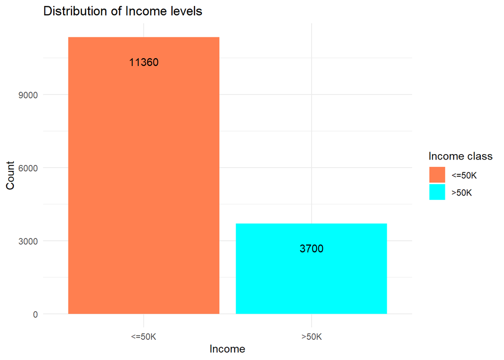

```r
# Show distribution of each class
income_summary_test <- adult_test |>
  group_by(income) |>
  count()

ggplot(income_summary_test, aes(x=factor(income), y = n, fill=factor(income))) +
  geom_col() +
  scale_x_discrete(labels = c('<=50K', '>50K')) +
  labs(title = "Distribution of Income levels", x = "Income", y = "Count",
       fill= "Income class") +
  geom_text(aes(label=n),
            position=position_nudge(y=-1000)) +
  theme_minimal() +
  scale_fill_manual(values=c("coral", "cyan"), labels = c("<=50K", ">50K"))
```

The classes are imbalanced as expected.

### Testing the Models

Using the `confusionMatrix()` function from the `caret` package.

```r
# Prepare test data (include interaction term that was included in X)
X_test <- model.matrix(income~. -1 + age*hours_per_week, data=adult_test)  # exclude intercept

# Check number of cols in X_test is the same as X
ncol(X_test) == ncol(X)
```

```
## [1] TRUE
```

```r
# Check feature names are the same
setdiff(colnames(X_test), colnames(X)) # expect 0
```

```
## character(0)
```

```r
setdiff(colnames(X), colnames(X_test)) # expect 0
```

```
## character(0)
```

```r
y_test <- adult_test$income
```

### Logistic Regression

```r
# Predict for Logistic Regression
logistic_pred <- predict(refined_model, newdata = adult_test, type = "response")
logistic_pred_class <- as.factor(ifelse(logistic_pred > 0.5, 1, 0)) # binary
logistic_cm <- confusionMatrix(logistic_pred_class, y_test) # confusion matrix
print(logistic_cm) # Accuracy = 84.66%
```

```
## Confusion Matrix and Statistics
##
##           Reference
## Prediction     0     1
##          0 10527  1477
##          1   833  2223
##
##                Accuracy : 0.8466
##                  95% CI : (0.8408, 0.8523)
##     No Information Rate : 0.7543
##     P-Value [Acc > NIR] : < 2.2e-16
##
##                   Kappa : 0.5604
##
##  Mcnemar's Test P-Value : < 2.2e-16
##
##             Sensitivity : 0.9267
##             Specificity : 0.6008
##          Pos Pred Value : 0.8770
##          Neg Pred Value : 0.7274
##              Prevalence : 0.7543
##          Detection Rate : 0.6990
##    Detection Prevalence : 0.7971
##       Balanced Accuracy : 0.7637
##
##        'Positive' Class : 0
##
```

```r
logistic_cm_miss <- 1 - logistic_cm$overall["Accuracy"] # miss-rate
names(logistic_cm_miss) <- "Logistic Regression Misclassification rate"
print(logistic_cm_miss)
```

```
## Logistic Regression Misclassification rate
##                                  0.1533865
```